# P2 Informe

Consumo de bebidas energéticas y rendimiento académico_

24/06/2022

[figure not shown]

## **Indice**

Se instala las librerías necesarias

```r
if(!require(readr)){install.packages(readr)}
if(!require(dplyr)){install.packages(dplyr)}
if(!require(stringi)){install.packages(stringi)}
```

```r
if(!require(ggplot2)){install.packages('ggplot2')}
if(!require(scales)){install.packages(scales)}
```

### **CORRECCIONES**

#### En base a la entrega 1 y a los comentarios realizados por el docente, los cambios que se han realizado son:

- Trabajamos los descriptores gráficos con un solo paquete de visualización (ggplot2).
- Utilizamos descriptores numéricos para describir a las variables.
- Hicimos correlaciones de variables para llegar a un análisis más exacto.
- Eliminamos las salidas de códigos innecesarios.
- Se especifica de manera clara el criterio de limpieza de la base de datos.
- Se corrigió la definición de población, muestra y tipo de muestreo.

### **TEMA**

“Estudio sobre la relación entre el consumo de bebidas energéticas y el rendimiento académico de los estudiantes de UTEC”

## **Introducción**

#### **Relevancia**

El periodo universitario es considerado como uno de los episodios más retadores en la vida académica de una persona, ya que es aquí donde se enfrentan a nuevos retos y desafíos que ponen a prueba todas sus capacidades, en su mayoría, intelectuales. En ese contexto, el tiempo es uno de los elementos del que más se adolece en esta etapa, por lo que los universitarios cada vez más recurren a bebidas energizantes con el fin de mantenerse despiertos largas horas para completar sus deberes académicos y con esto obtener un mejor rendimiento en la universidad y con ello mejores calificaciones. En este sentido, creemos llamativo e interesante estudiar el impacto que tiene el consumo de bebidas energizantes en relación con el rendimiento académico de los jóvenes universitarios de UTEC, para así identificar si existe una relación directa entre ambas variables, ya que resulta ser un tema del cual somos partícipes y que acontece a nuestro alrededor.

#### **Planificación**

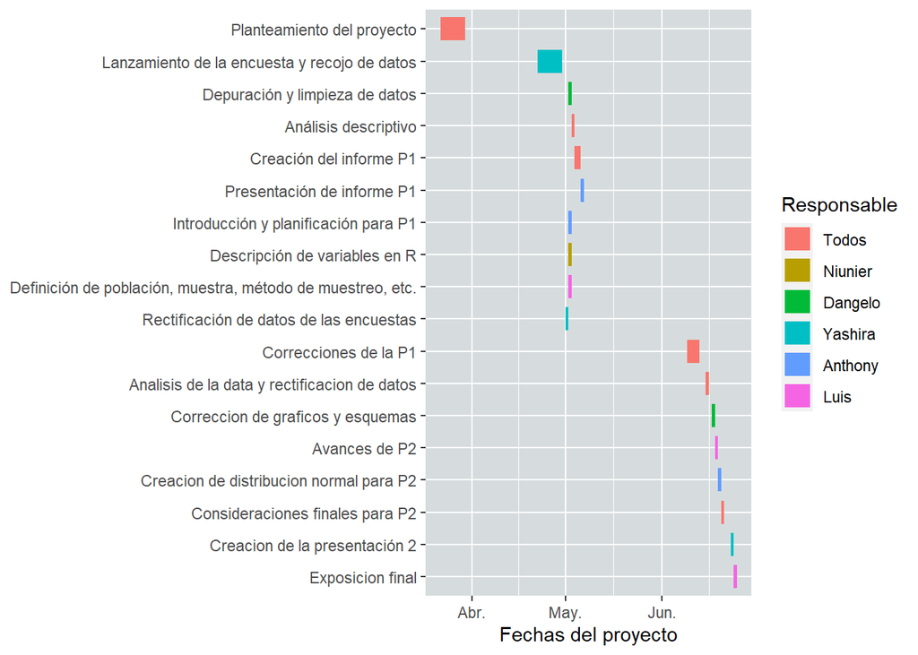

## **Datos**

#### **Recolección de datos**

- Para obtener los datos de los estudiantes de UTEC sobre el consumo de bebidas energéticas estamos efectuando encuestas a través de un formulario creado en google forms, nuestros encuestados son jóvenes universitarios de la Universidad de Ingeniería y Tecnología (UTEC), que se encuentran cursando al menos segundo ciclo.

#### **Población, muestra y muestreo**

- **Población**:

Para nuestro estudio la población estudiada son los estudiantes de la Universidad de Ingeniería y Tecnología que estén cursando estudios actualmente; es necesario precisar que la población está delimitada desde aquellos estudiantes de segundo ciclo hasta aquellos del décimo ciclo.

Unidad muestral:

Dado que la encuesta fue lanzada de forma voluntaria para su realización así como el estudio solo admite estudiantes de ciclos superiores al segundo, el tipo de muestreo es por conveniencia.

#### **Variables**

- **Relación** (Categórica nominal): Expectativa que poseen los estudiantes acerca de si el consumo de cafeína influye en su rendimiento, las opciones se restringen a *Si*, *No* o *No estoy seguro* y no existe un orden entre las opciones.

Se pueden mostrar en el siguiente gráfico de barras.

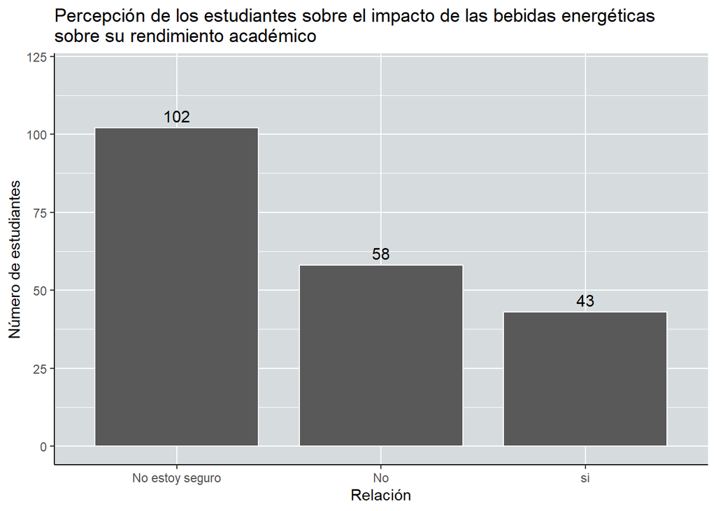

- **Bebida energética** (Categórica nominal): El tipo de bebida energizante que consume, es una variable nominal y solo se restringe a bebidas que contengan cafeína.

Podemos observar su distribución en el siguiente gráfico, en el cual se muestra que la moda, o la bebida que los estudiantes consumen en su mayoría es el café.

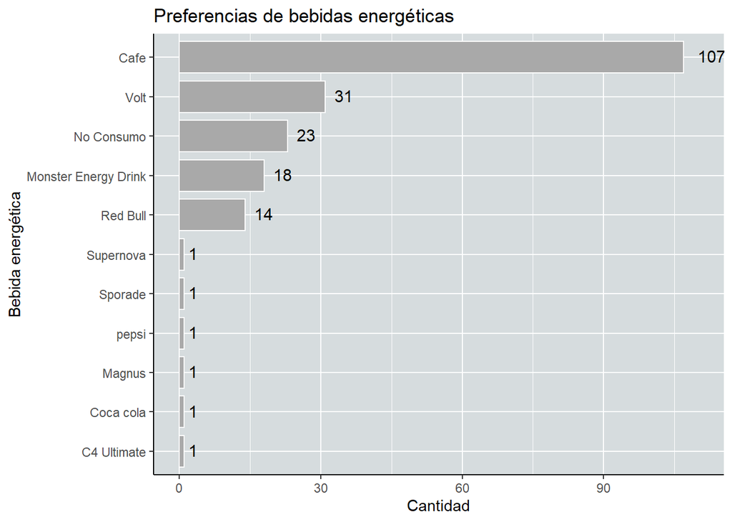

- **Ranking** (Categórica nominal): Ranking académico en el que se encuentra el estudiante, el estudiante puede pertenecer al *DECIMO SUPERIOR*, *QUINTO SUPERIOR*, *TERCIO SUPERIOR* o a *Ninguno de ellos*, estos valores no presentan un orden entre ellos así como no se pueden realizar operaciones matemáticas con estos valores.

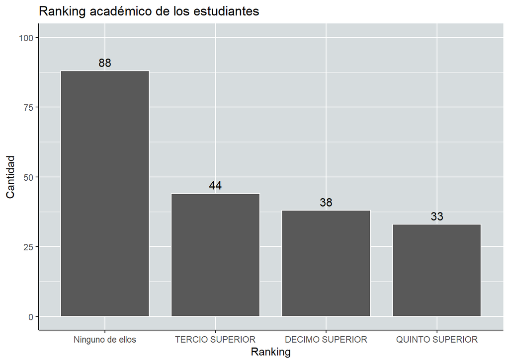

- **Cantidad de cursos matriculados** (Numérica discreta): Esta variable hace referencia a la cantidad de cursos que un alumno se ha matriculado en el ciclo anterior; es una variable numérica discreta, debido a que la cantidad de cursos que puede tomar un estudiante en un ciclo es limitada, por lo tanto, es contable.

A continuación se muestra su gráfica y su análisis.

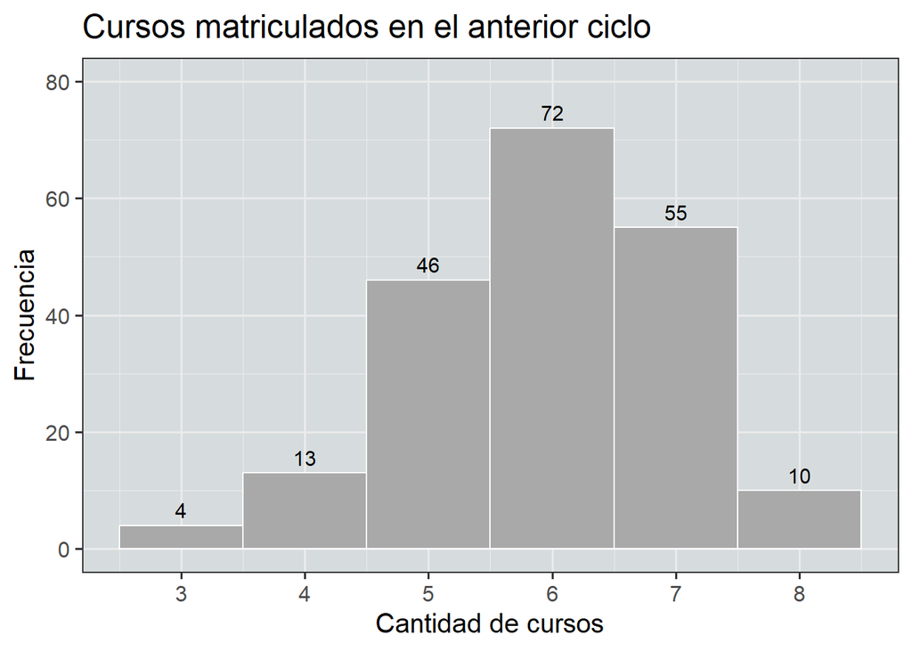

```
## [1] NA
```

En promedio los estudiantes en el anterior ciclo se matricularon en 6 cursos

```
## [1] 6
```

La mayor cantidad de estudiantes se matricularon en 6 cursos

```
## [1] NA NA
```

```
## [1] NA
```

```
## [1] NA
```

- **Horas despierto con bebidas energéticas** (Numérica continua): Esta variable hace referencia a la cantidad de horas extra que un alumno se ha mantenido despierto habiendo ingerido bebidas energéticas; es numérica continúa, debido a que este es un valor continuo que se puede expresar en una cantidad infinita de valores.

A continuación se muestra una gráfica que muestra las horas extras que los estudiantes permanecen despiertos al consumir una bebida energética.

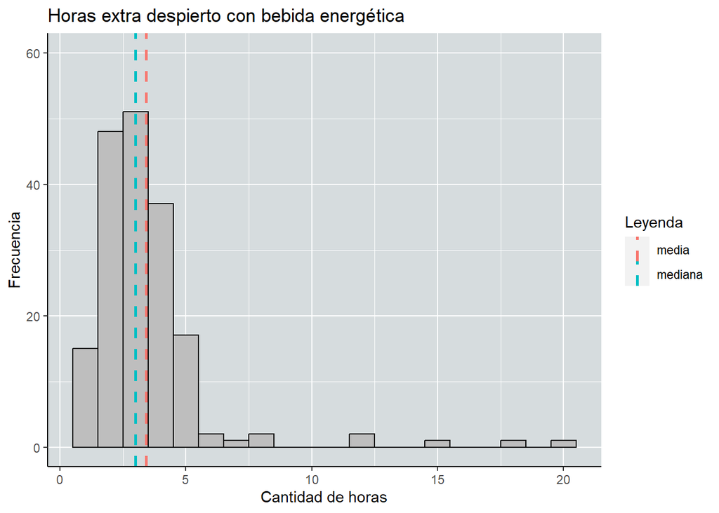

La media y la mediana de esta variable son las siguientes.

```
## [1] 3.42
```

```
## [1] 3
```

Ahora calculamos la desviación estándar y el coeficiente de variación de los valores.

```
## [1] 2.48
```

```
## [1] 0.72
```

- **Horas dormido con bebida energética** (Numérica continua): Este tipo de variable hace referencia a las horas que un estudiante ha dormido habiendo ingerido bebidas energéticas; es una numérica continua, ya que al trabajar con el tiempo este posee un valor numérico que puede tomar una cantidad infinita de valores.

A continuación se muestra la distribución de las horas que duerme un estudiante cuando consume una bebida energética.

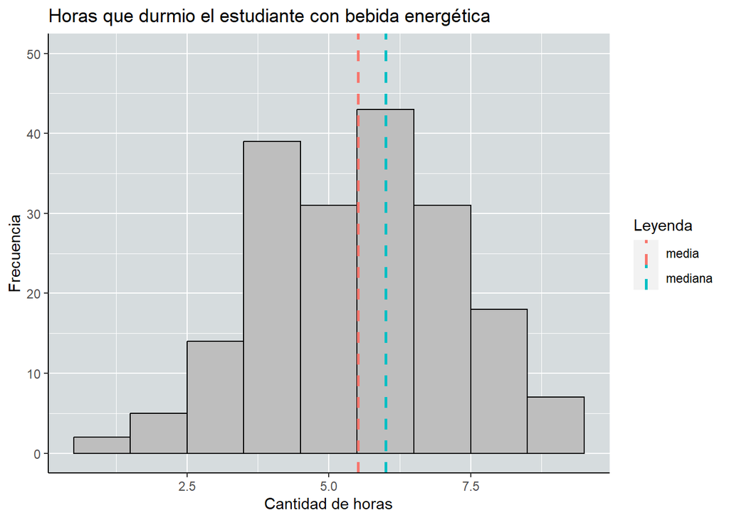

De la gráfica se puede apreciar que el número de horas de sueño de un estudiante que ha consumido una bebida energética varía en su mayoría entre 5 y 6 horas, de hecho esta es la clase modal del histograma. Por otro lado, podemos apreciar que nuestra variable no tiene un sesgo pronunciado hacia la derecha, por lo que se puede considerar que es una distribución sin sesgos definidos por valores *‘outliers’*.

La media y la mediana de esta variable son los siguientes:

```
## [1] 5.51
```

```
## [1] 6
```

Ahora procedemos a calcular la desviación estándar y el coeficiente de variación.

```
## [1] 1.73
```

```
## [1] 0.31
```

Al calcular la desviación estándar de los datos, podemos identificar que no están tan alejados de la media, ya que su valor resulta ser menor en comparación con esta. Asimismo, con el valor del coeficiente de variación podemos identificar que nuestra variable no tiene gran cantidad de datos dispersos.

- **Hora dormido sin bebida energética** (Numérica continua): Esta variable hace referencia a la cantidad de horas que duerme el estudiante sin consumir bebidas energéticas.Al igual que la variable anterior, no existe un rango contable de valores que esta variable puede tomar, ya que las respuestas de los estudiantes son muy variadas, solo habiendo restricción en cuanto al máximo y mínimo valor.

A continuación se muestra la distribución de las horas que duerme un estudiante cuando no consume una bebida energética.

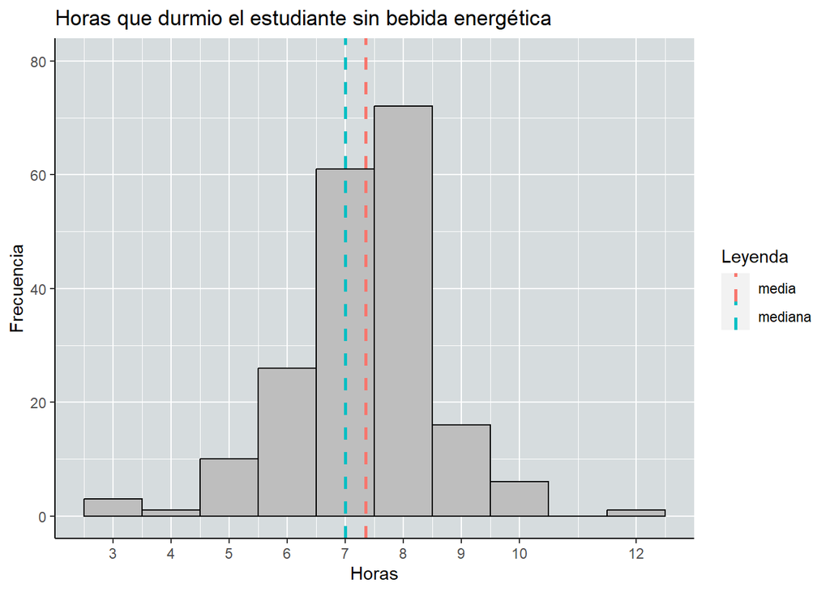

La media y la mediana de esta distribución de valores es la siguiente.

```
## [1] 7.35
```

```
## [1] 7
```

Respecto a la gráfica, podemos ver que la cantidad de horas que duerme un estudiante sin haber consumido bebidas energéticas se concentra en el intervalo de horas de 6.5 a 8.5. Esto lo podemos comprobar con nuestros descriptores numéricos, en donde se puede observar que el promedio de horas en que los estudiantes duermen sin haber consumido bebidas energéticas es de 7 horas. De igual forma, esta variable tiene una distribución casi simétrica dado que la mediana es cercana a la media.

Ahora procedemos a calcular la desviación estándar y el coeficiente de variación de estos datos.

```
## [1] 1.27
```

```
## [1] 0.17
```

Ahora haremos una comparativa entre las horas que duerme en promedio un estudiante cuando consume alguna bebida energizante y cuando no lo hace.

Los promedios son los siguientes:

```
## [1] 5.51
```

```
## [1] 7.35
```

Al hacer dicha comparativa encontramos una diferencia aproximada de dos horas, es decir, que cuando los estudiantes consumen una bebida energizante, aproximadamente dormirán 2 horas menos que cuando no la consumen, las cuales podrían ser utilizadas para culminar sus actividades académicas.

- **Promedio general de la carrera** (Numérica discreta): Esta variable hace referencia al promedio general que obtuvo el estudiante el ciclo anterior a la encuesta. La UTEC trabaja los promedios con 2 decimales. Por lo tanto, esta variable es numérica discreta, ya que tomará un amplio rango de valores, pero no infinitos.

A continuación se muestran las notas promedio de los estudiantes.

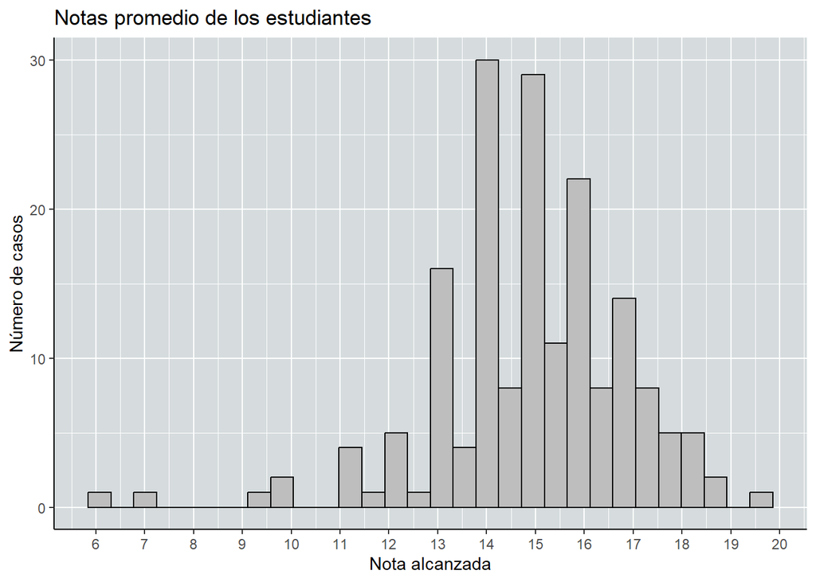

A continuación calculamos la media y la mediana de estos valores

```
## [1] 14.91
```

```
## [1] 15
```

- **Desde que horas la consume** (Numérica discreta): Esta variable indica la hora en que los estudiantes empiezan a consumir bebidas energéticas de forma habitual. Al restringir la variable a horas enteras y en un rango de 0 a 23 horas, se considera que esta variable es discreta.

A continuación se muestra la distribución de las horas en la que un alumno comienza a consumir bebidas energéticas durante el día.

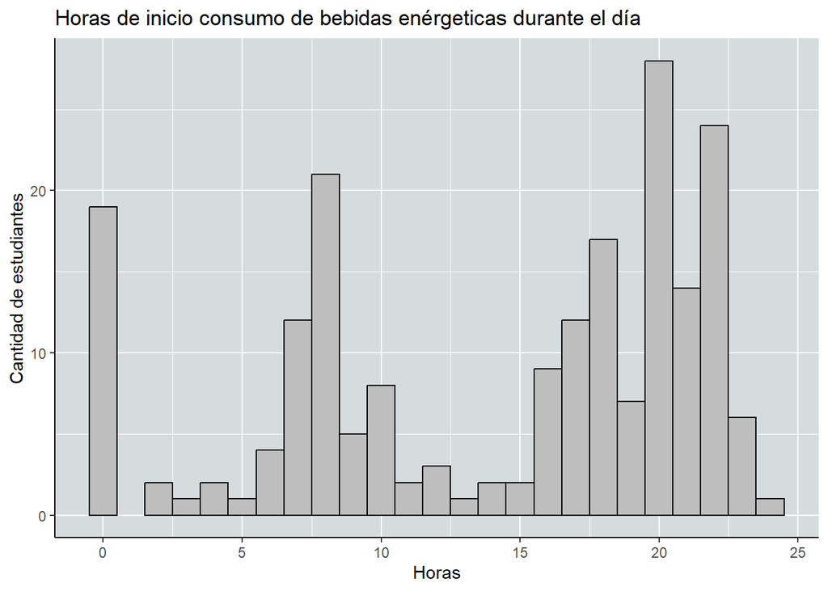

```
## [1] 17
```

```
## [1] 14.19
```

Respecto a la gráfica, podemos mencionar que la moda es 20, es decir, los estudiantes en su mayoría consumen bebidas energéticas a partir de las 8 pm. Analizando esto con nuestros descriptores numéricos, podemos decir que la distribución de la hora en que los estudiantes inician a consumir bebidas energéticas tiene un sesgo hacia la izquierda, dado que la media es menor que la mediana, y la mediana menor a la moda. Además, podemos evidenciar que su consumo no se limita a horas de la noche, sino que abarca gran parte de las horas diurnas.

- **Ciclo** (Categórica ordinal): Se refiere al ciclo en el que el estudiante empezó a consumir bebidas energéticas. Dado que se tiene una cantidad definida y exacta de la cantidad de ciclos, la variable es categórica ordinal.

A continuación se muestra la distribución de los ciclos que los estudiantes comenzaron a consumir bebidas energéticas.

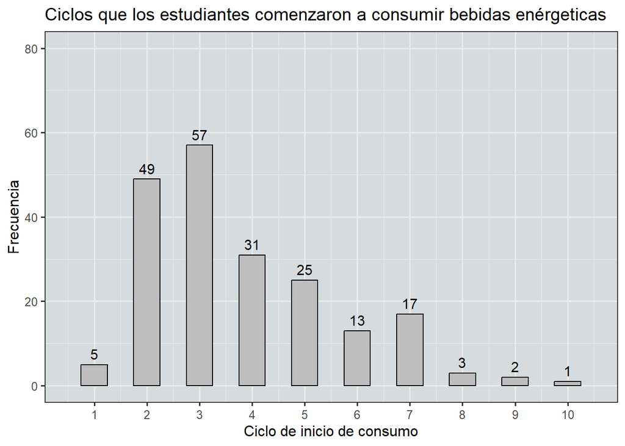

Respecto a esta variable, podemos mencionar que la moda, o el ciclo en el cual los estudiantes tuvieron mayor tendencia a empezar a consumir bebidas energizantes, es en el tercer ciclo, lo que se evidencia en el gráfico presentado, ello se podría relacionar con el ámbito académico y la exigencia que existe para presentar actividades académicas, por lo cual el tiempo de estudio juega un papel fundamental.

- **Miligramos de cafeína** (Numérica continua): Esta variable hace referencia a la cantidad de cafeína en miligramos por cada litro que contiene la bebida energizante que consume el estudiante. Dado que no tenemos un rango contable de valores que puede tomar dicha variable, se considera como numérica continua. —| Para el caso de esta variable, los datos de mg de cafeína por litro de bebida energizante son datos extraídos de Internet y como parte de la información pública, por ende no se puede hablar de algún análisis con descriptores numéricos, ya que la cantidad depende de cada tipo de bebida consumido por los estudiantes. —|
- **Consumo promedio diario en litros** (Numérica continua): Se refiere a la cantidad en Litros de la bebida energética que el estudiante consume diariamente. Es numérica porque los litros se miden numéricamente y continua porque puede tomar una cantidad incontable de valores dentro de un rango no definido.

Dado que la variable contiene diversos datos cercanos entre sí, además que sigue una distribución continua se presentan de la siguiente forma.

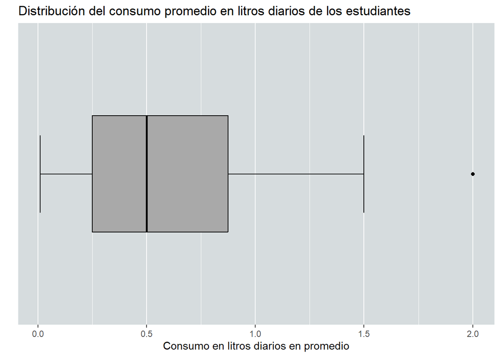

```
## [1] 0.5
```

```
## [1] 0.59
```

```
## [1] 0.62
```

- **Consumo semana 1-semana 5** (Numérica continúa): Cantidad en litros que el estudiante consume semanalmente durante el periodo de la semana 1 a 5. Es numérica continua, ya que los valores ingresados contienen decimales, por lo tanto, esta variable no tiene un límite definido y los estudiantes pueden colocar cualquier cantidad.

A continuación se muestra la distribución del promedio en litros que los estudiantes consumieron en el periodo de la semana 1 a la 5 en el ciclo 2021-2.

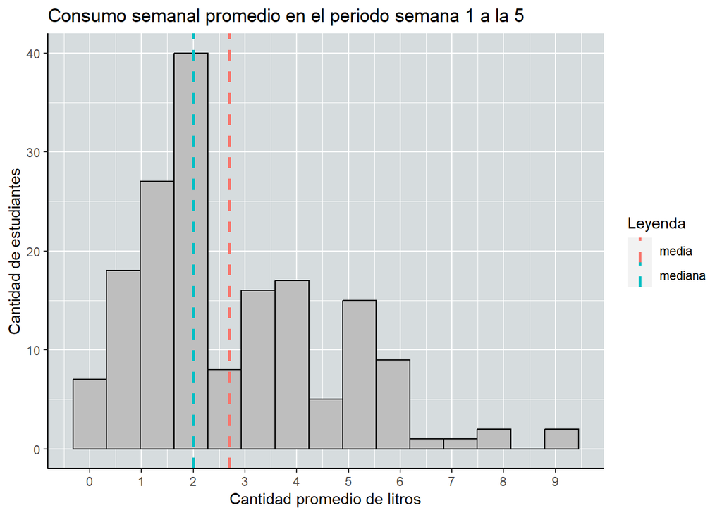

Procedemos a calcular sus descriptores numéricos.

```
## [1] 2
```

```
## [1] 2.7
```

Respecto a la variable “consumo de la semana 1 a la semana 5”, podemos analizar que tiene un sesgo hacia la derecha, dado que la media es mayor que la mediana, además que no hay una concentración respecto de esta.

- **Consumo semana 6-semana 10** (Numérica continua): Cantidad en litros que el estudiante consume semanalmente durante el periodo de la semana 6 a 10. Es numérica continua, ya quelos valores ingresados contienen decimales, por lo tanto, esta variable no tiene un límite definido y los estudiantes pueden colocar cualquier cantidad.

A continuación se muestra la distribución del promedio en litros que los estudiantes consumieron en el periodo de la semana 6 a la 10 en el ciclo 2021-2.

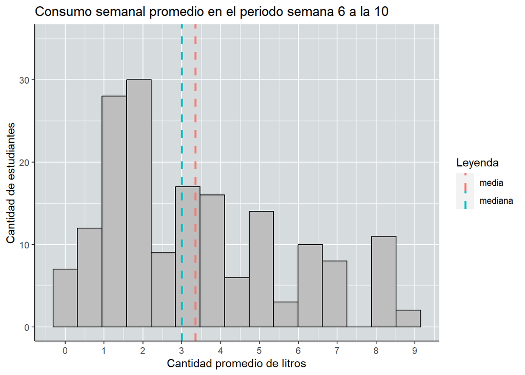

A continuación calculamos sus descriptores numéricos.

```
## [1] 3
```

```
## [1] 3.35
```

Respecto a la variable “consumo de la semana 6 a la semana 10”, podemos mencionar, que tiene una leve distribución sesgada hacia la derecha, dado que el valor de la media resulta ser mayor al de la mediana. Por otro lado, en estas semanas aumenta en promedio el consumo de bebidas energizantes respecto de las primeras semanas.

- **Consumo semana 11- semana 16** (Numérica continua): Cantidad en litros que el estudiante consume semanalmente durante el periodo de la semana 11 a 16. Es numérica continua continua, ya que los valores ingresados contienen decimales, por lo tanto, esta variable no tiene un límite definido y los estudiantes pueden colocar cualquier cantidad.

A continuación se muestra la distribución del promedio en litros que los estudiantes consumieron en el periodo de la semana 11 a la 16 en el ciclo 2021-2.

[figure not shown]

Procedemos a calcular los descriptores numéricos:

```
## [1] 2.4
```

```
## [1] 3.54
```

Respecto a la variable “consumo de la semana 11 a la semana 16”, podemos analizar basándonos en sus descriptores numéricos que hay una sesgo a la derecha, ya que la media es mayor a la mediana. Por otro lado, podemos apreciar que el consumo promedio se mantiene en este periodo respecto al periodo anterior, dado que no hay una gran diferencia en el consumo.

#### **Clasificación de variables**

[output not shown]

#### **Limpieza de base de datos**

- Llamado a las librerías

se procede a seleccionar las variable útiles para el esudio y a cambiar el nombre de las variables + Lectura de la data

```r
DF <- read_csv("Encuesta.csv", col_types = "cccccccnncnnnncnnnnccc")
```

- Revisión de la data:

Número de observaciones y variables respectivamente.

```
## [1] 203  22
```

- Nombre original de las variables

```
##  [1] "Marca temporal"
##  [2] "Dirección de correo electrónico"
##  [3] "Sexo"
##  [4] "Edad en años"
##  [5] "Selecciona tu carrera"
##  [6] "Ciclo"
##  [7] "Código de Alumno"
##  [8] "Ciclo que inicio el consumo de bebidas energéticas"
##  [9] "Cursos"
## [10] "Bebida energética"
## [11] "Miligramos de Cafeína"
## [12] "Consumo promedio diario en litros (L)"
## [13] "Horas extras despierto con bebida energética"
## [14] "Horas dormido con bebida energética"
## [15] "Horas dormido sin bebida energética"
## [16] "Consumo Semana 1 - Semana 5"
## [17] "Consumo Semana 6 - Semana 10"
## [18] "Consumo Semana 11 - Semana 16"
## [19] "Promedio General de la carrera"
## [20] "Ranking"
## [21] "Desde que horas la consume"
## [22] "Relacion"
```

- Selección de las variables que son útiles para el estudio

```
##  [1] "Ciclo"
##  [2] "Ciclo que inicio el consumo de bebidas energéticas"
##  [3] "Cursos"
##  [4] "Bebida energética"
##  [5] "Miligramos de Cafeína"
##  [6] "Consumo promedio diario en litros (L)"
##  [7] "Horas extras despierto con bebida energética"
##  [8] "Horas dormido con bebida energética"
##  [9] "Horas dormido sin bebida energética"
## [10] "Consumo Semana 1 - Semana 5"
## [11] "Consumo Semana 6 - Semana 10"
## [12] "Consumo Semana 11 - Semana 16"
## [13] "Promedio General de la carrera"
## [14] "Ranking"
## [15] "Desde que horas la consume"
## [16] "Relacion"
```

- Renombramos las variables de la nueva base de datos `DD`

```
##  [1] "Ciclo"                    "Inicio_consumo"
##  [3] "Cant_cursos"              "Bebida"
##  [5] "cafeina_mg"               "Consumo_dia"
##  [7] "desp_con_bebida"          "dormido_con_bebida"
##  [9] "dormido_sin_bebida"       "Consumo_1_5"
## [11] "Consumo_6_10"             "Consumo_11_16"
## [13] "Nota_Promedio"            "Ranking"
## [15] "Incio_horas_consumo"      "Creeencia_de_Efectividad"
```

- Revisión del inicio y el final de la base de datos: Al leer el principio y el final de la base de datos nos damos una idea de los posibles problemas con ella.

| Ciclo | Inicio_consumo | Cant_cursos | Bebida | cafeina_mg | Consumo_dia | desp_con_bebida | dormido_con_bebida | dormido_sin_bebida | Consumo_1_5 | Consumo_6_10 | Consumo_11_16 | Nota_Promedio | Ranking | Incio_horas_consumo | Creeencia_de_Efectividad |
| --- | --- | --- | --- | --- | --- | --- | --- | --- | --- | --- | --- | --- | --- | --- | --- |
| 2 | 1 | 7 | Volt | 100 | 0.1 | 4 | 4 | 7 | 10 | 4.0 | 6 | 13.9 | Ninguno de ellos | 20 | No estoy seguro |
| 8 | 3 | 5 | Red Bull | NA | 0.5 | 5 | 3 | 7 | 15 | 18.0 | 20 | 13.0 | Ninguno de ellos | 16 | No estoy seguro |
| 7 | 1 | 5 | Café | 20 | 0.4 | 3 | 5 | 7 | 7 | 9.0 | 11 | 14.2 | Ninguno de ellos | 7 | si |
| 3 | 1 | 4 | Monster Energy Drink | NA | 2.0 | 3 | 5 | 8 | 3 | 2.0 | 3 | 15.0 | Ninguno de ellos | 22 | No estoy seguro |
| 3 | 1 | 5 | Red Bull | NA | 0.5 | 2 | 6 | 7 | 2 | 2.5 | 2 | 14.8 | Ninguno de ellos | 17 | No |
| 4 | 1 | 6 | Café | NA | 1.0 | 3 | 8 | 8 | 1 | 1.0 | 1 | 15.0 | QUINTO SUPERIOR | 18 | si |

| Ciclo | Inicio_consumo | Cant_cursos | Bebida | cafeina_mg | Consumo_dia | desp_con_bebida | dormido_con_bebida | dormido_sin_bebida | Consumo_1_5 | Consumo_6_10 | Consumo_11_16 | Nota_Promedio | Ranking | Incio_horas_consumo | Creeencia_de_Efectividad |
| --- | --- | --- | --- | --- | --- | --- | --- | --- | --- | --- | --- | --- | --- | --- | --- |
| 6 | 1 | 6 | Café | 15.0 | 0.40 | 2 | 5 | 5 | 1.50 | 2.00 | 1.50 | 17.40 | DECIMO SUPERIOR | 8 | No estoy seguro |
| 6 | 7 | 6 | No Consumo | 0.0 | 0.00 | 0 | 0 | 6 | 0.00 | 0.00 | 0.00 | 18.32 | DECIMO SUPERIOR | 0 | No |
| 5 | 1 | 5 | Café | 27.8 | 0.46 | 5 | 3 | 5 | 2.00 | 3.00 | 2.00 | 18.30 | DECIMO SUPERIOR | 22 | No estoy seguro |
| 4 | 4 | 7 | Red Bull | NA | 0.00 | 3 | 9 | 7 | 5.00 | 8.00 | 8.00 | 14.20 | Ninguno de ellos | 22 | No estoy seguro |
| 5 | 5 | 7 | Café | 13.9 | 0.23 | 3 | 7 | 9 | 0.23 | 0.69 | 0.69 | 16.70 | DECIMO SUPERIOR | 8 | No estoy seguro |
| 3 | 2 | 6 | Volt | 0.0 | 0.50 | 4 | 3 | 8 | 4.00 | 6.00 | 4.00 | 17.15 | TERCIO SUPERIOR | 23 | si |

### **Corrección de las variables**

**Corrección de la variable `Bebida`**

- Se observa que la variable `Bebida` presenta algunos datos que tienen el mismo significado de *No Consumo*, otros datos no cumplen con la restricción de contener cafeína para ser considerados, por lo que se les considera como *N.A*

```
##  [1] "Volt"                       "Red Bull"
##  [3] "Café"                       "Monster Energy Drink"
##  [5] "pepsi por el exceso azucar" "No consumo"
##  [7] "Ninguna"                    "Ninguno"
##  [9] "Coca cola"                  "ninguno"
## [11] "Gatorade"                   "Sporade"
## [13] "Magnus"                     "Maca con leche"
## [15] "C4 Ultimate"                "todas las anteriores"
## [17] "No Consumo"                 "Supernova"
```

| Bebida | n |
| --- | --- |
| C4 Ultimate | 1 |
| Café | 107 |
| Coca cola | 1 |
| Magnus | 1 |
| Monster Energy Drink | 18 |
| No Consumo | 23 |
| Red Bull | 14 |
| Sporade | 1 |
| Supernova | 1 |
| Volt | 31 |

[output cut: 2 more lines]

- Asimismo, eliminamos las tildes

```
##  [1] "Volt"                 "Red Bull"             "Café"
##  [4] "Monster Energy Drink" "pepsi"                "No Consumo"
##  [7] "Coca cola"            NA                     "Sporade"
## [10] "Magnus"               "C4 Ultimate"          "Supernova"
```

| Bebida | n |
| --- | --- |
| C4 Ultimate | 1 |
| Cafe | 107 |
| Coca cola | 1 |
| Magnus | 1 |
| Monster Energy Drink | 18 |
| No Consumo | 23 |
| Red Bull | 14 |
| Sporade | 1 |
| Supernova | 1 |
| Volt | 31 |

[output cut: 2 more lines]

**Corrección de la variable `cafeína_mg`**

- Se observa que existe un gran número de valores *NA*

```
## [1] 80
```

En total hay 80 observaciones que contienen *NA* en la variable `cafeina_mg`.

- Se reemplaza los valores *NA* en `cafeina_mg` que corresponden a productos procesados, los cuales contienen determinada cantidad de miligramos de cafeína por litro del producto.

| Bebida | cafeina_mg |
| --- | --- |
| Volt | 100.000 |
| Red Bull | NA |
| Cafe | 20.000 |
| Monster Energy Drink | NA |
| Red Bull | NA |
| Cafe | NA |
| Cafe | NA |
| Cafe | 2.000 |
| Cafe | 24.000 |
| Cafe | NA |

[output cut: 193 more lines]

| Bebida | cafeina_mg |
| --- | --- |
| Volt | 103.000 |
| Red Bull | 300.000 |
| Cafe | 20.000 |
| Monster Energy Drink | 290.000 |
| Red Bull | 300.000 |
| Cafe | NA |
| Cafe | NA |
| Cafe | 2.000 |
| Cafe | 24.000 |
| Cafe | NA |

[output cut: 193 more lines]

- Se observa que existen valores que son atípicos, para este caso optamos por comunicarnos con los encuestados determinamos que habían colocado la cantidad de café en miligramos mas no de cafeína, con ello obtuvimos las siguientes correcciones Valores de la variable *cafeina_mg* limpios.

Los valores de *cafeina_mg* luego de la limpieza son:

```
##  [1] 103.000 300.000  20.000 290.000      NA  24.000 100.000   5.000  30.000
## [10]  10.000  90.000 110.000 500.000 200.000   1.000  50.000  80.000  40.000
## [19] 250.000 800.000  11.000  85.000   7.000 640.000 400.000 900.000  13.900
## [28]  41.700  10.425  69.500  20.850  27.800  20.800 180.000  35.000  25.000
## [37]  47.000  39.000  15.000
```

**Corrección de la variable `dormido_sin_bebida`**

- Observamos que no cumple con las restricción de ser numérica, utilizamos el siguiente criterio de corrección, aquellas variables que se encuentren en un rango corto las colocamos como el promedio entre los extremos, los datos que representen una hora determinada la pasamos a un valor numérico y aquellos datos que no se puedan interpretar como un valor numérico son tomadas como *NA*.

```
##  [1] "7"     "8"     "5-6"   "6"     "5"     "81"    "12"    "9:30"  "7-8"
## [10] "10"    "9"     "Sí"    "4"     "Si"    "8 o 9" "3"     "0"
```

- Valores reales aceptados

```
##  [1]  7.0  8.0  5.5  6.0  5.0 12.0  9.5  7.5 10.0  9.0   NA  4.0  8.5  3.0
```

**Corrección de las variables `Consumo_1_5`, `Consumo_6_10` y `Consumo_11_16`**

- Estas variables presentan datos que resultan atípicos comparado con el resto de encuestados, al consultarles, algunos mencionaron que confundieron las cantidades al insertarlas como mililitros en lugar de litros. Por otro lado, algunos entendieron mal la consigna y respondieron con todos los litros que consumen durante este periodo en lugar del promedio semanal que consumen. Procedemos a cambiar estos datos. En el caso en que no conseguimos respuesta se cambia el dato a un *NA*

**Corrección de las variables `Consumo_1_5`**

```
##  [1]   10.000   15.000    7.000    3.000    2.000    1.000    0.400    7.098
##  [9]   25.000    5.000    0.500    5.250    0.250    4.000   30.000    6.000
## [17]    1.250 3000.000   20.000    0.000   75.000    2.500   40.000    8.000
## [25]   24.000  473.000   11.500    0.600  310.000    3.500  300.000   18.000
## [33]    4.500  805.000    0.230    4.600    1.150    2.415    8.800    0.360
## [41]    5.750    1.840    0.690   32.200    1.750    6.900    0.460    2.070
## [49]    9.200    2.300    0.080   14.490    3.450    8.050   16.100   23.000
## [57]   12.000    0.560    1.500
```

- Variable `Consumo_1_5`corregida

```
##  [1] 2.000 3.000 1.750 1.000 0.400 1.420 5.000 0.500 5.250 0.250 4.000 6.000
## [13] 1.250    NA 2.500 8.000 4.800 0.473 2.300 0.600 3.100 3.500 3.600 4.500
## [25] 0.805 0.230 4.600 1.150 2.415 8.800 0.360 5.750 1.840 0.690 6.400 6.900
## [37] 0.460 2.070 9.200 0.080 2.898 3.450 8.050 3.220 0.420 0.560 1.500
```

**Corrección de la variable `Consumo_6_10`**

```
##  [1]    4.0000   18.0000    9.0000    2.0000    2.5000    1.0000    3.0000
##  [8]    0.7000    5.6784   20.0000   14.0000    5.0000    0.5000    5.2500
## [15]    0.2500    8.0000    1.2500   10.0000 2000.0000    0.0000    7.0000
## [22]   75.0000    6.0000   35.0000    1.5000    1.4190   29.0000    1.2000
## [29]  473.0000   10.5000    0.3000   12.0000   15.8000    3.5000   15.0000
## [36]    0.8000    4.5000 1240.0000  500.0000    8.5000    1.1500    6.4400
## [43]    0.4600    4.6000    2.4150    8.3000    0.2300    0.3600    5.7500
## [50]    2.7600    0.6900   48.3000    1.7500    1.3800    2.5700    6.3600
## [57]    3.4500    0.1700   15.1000  146.0000   16.1000    5.0600   50.0000
## [64]    0.4500    0.7500
```

- Variable `Consumo_6_10`corregida

```
##  [1] 4.0000 3.6000 9.0000 2.0000 2.5000 1.0000 3.0000 0.7000 5.6784 2.8000
## [11] 5.0000 0.5000 5.2500 0.2500 8.0000 1.2500     NA 7.0000 6.0000 1.5000
## [21] 1.4190 5.8000 1.2000 4.7300 2.1000 0.3000 2.4000 3.1600 3.5000 0.8000
## [31] 4.5000 1.2400 8.5000 1.1500 6.4400 0.4600 4.6000 2.4150 8.3000 0.2300
## [41] 0.3600 5.7500 2.7600 0.6900 1.7500 1.3800 2.5700 6.3600 3.4500 0.1700
## [51] 1.4600 3.2200 5.0600 0.4500 0.7500
```

**Corrección de la variable `Consumo_11_16`**

```
##  [1]    6.000   20.000   11.000    3.000    2.000    1.000    5.000    0.700
##  [9]    9.464   30.000   15.000    4.000    5.250    4.500    0.200   40.000
## [17]    8.000    1.250   12.000   10.000 4000.000    0.000    0.500   75.000
## [25]    7.000    9.000    2.838   33.000    1.750    0.250  473.000   13.000
## [33]    0.300    1.500   11.300    0.800  620.000    3.500  500.000  946.000
## [41]    1.840    6.440    0.690    1.610    2.415   10.100    0.360    5.750
## [49]    3.450   56.350    2.070    0.230    2.300    7.360    4.600    0.210
## [57]    8.500    4.140    2.500   16.100    5.060   60.000    0.340    0.750
## [65]    1.380
```

- Variable `Consumo_11_16`corregida

```
##  [1]  6.000  4.000  1.100  3.000  2.000  1.000  5.000  0.700  9.464  5.250
## [11]  4.500  0.200     NA  8.000  1.250  2.400  0.500  7.000  9.000  2.838
## [21]  1.750  0.250  0.473 13.000  0.300  1.500  2.260  0.800  0.620  3.500
## [31]  0.946  1.840  6.440  0.690  1.610  2.415 10.100  0.360  5.750  3.450
## [41] 56.350  2.070  0.230  2.300  7.360  4.600  0.210  8.500  4.140  2.500
## [51]  3.220  5.060  0.340  0.750  1.380
```

**Corrección de la variable `Nota_Promedio`**

- Se observa que existen que exceden el límite restringido, en este caso preferimos convertirlas a *NA*

| Ciclo | Inicio_consumo | Cant_cursos | Bebida | cafeina_mg | Consumo_dia | desp_con_bebida | dormido_con_bebida | dormido_sin_bebida | Consumo_1_5 | Consumo_6_10 | Consumo_11_16 | Nota_Promedio | Ranking | Incio_horas_consumo | Creeencia_de_Efectividad |
| --- | --- | --- | --- | --- | --- | --- | --- | --- | --- | --- | --- | --- | --- | --- | --- |
| 2 | 1 | 6 | Cafe | 5.000 | 0.40 | 2 | 4 | 7 | 2.000 | 4.000 | 4.500 | 3.200 | QUINTO SUPERIOR | 20 | No estoy seguro |
| 3 | 1 | 5 | Volt | 103.000 | 0.50 | 4 | 2 | 5 | 5.000 | 2.000 | 2.000 | 2.000 | TERCIO SUPERIOR | 8 | si |
| 4 | 2 | 7 | Monster Energy Drink | 290.000 | 473.00 | 5 | 3 | 6 | 1.000 | 1.500 | 2.000 | 1.500 | QUINTO SUPERIOR | 22 | si |
| 2 | 1 | 6 | Volt | 103.000 | 0.20 | 3 | 6 | 7 | 1.000 | 1.000 | 2.000 | 1.500 | Ninguno de ellos | 7 | No estoy seguro |
| 3 | 3 | 3 | Cafe | 30.000 | 625.00 | 4 | 8 | 10 | 1.000 | NA | NA | 4.000 | TERCIO SUPERIOR | 8 | No |
| 3 | 3 | 6 | Red Bull | 300.000 | 5.00 | 2 | 7 | 4 | 5.000 | 5.000 | 8.000 | 4.000 | TERCIO SUPERIOR | 8 | No |
| 2 | 2 | 7 | Sporade | 800.000 | 0.00 | NA | 9 | 9 | 1.000 | NA | NA | 1.000 | QUINTO SUPERIOR | 0 | No |
| 3 | 2 | 7 | NA | NA | 1.00 | 3 | 3 | 5 | 6.000 | 8.000 | 1.000 | 24.000 | DECIMO SUPERIOR | 23 | No estoy seguro |
| 6 | 5 | 6 | Cafe | 20.000 | 0.50 | 4 | 7 | 9 | 2.000 | 5.000 | 6.000 | 4.000 | Ninguno de ellos | 18 | No estoy seguro |
| 3 | 1 | 7 | Volt | 103.000 | 310.00 | 2 | 7 | 7 | 3.100 | 1.240 | 0.620 | 5.000 | QUINTO SUPERIOR | 18 | No |

[output cut: 14 more lines]

Luego de la corrección

```
##  [1] 13.90 13.00 14.20 15.00 14.80 14.00 16.00 15.90 17.04 17.50    NA 16.60
## [13] 16.42 17.75 18.30 14.90 17.89 17.84 12.00 17.40 14.67 16.98 11.00 11.50
## [25] 13.92 14.35 15.26 15.69 16.53 10.00 16.12 16.16 15.70 17.00 14.81 15.11
## [37] 14.11 14.48 15.18 13.02 12.67 15.30 16.50 15.22 16.65 17.23 16.10  6.00
## [49] 17.46 13.64 14.92 13.70 15.40 15.52 16.55 14.77 15.65 18.77 15.42 15.20
## [61] 18.00 18.03 13.95 13.35 18.58 16.05 17.76 19.55  9.25  7.00 14.03 11.29
## [73] 13.60 16.40 15.03 15.23 15.60 14.65 14.70 16.78 13.20 15.67 15.17 17.74
## [85] 14.89 14.50 18.32 16.70 17.15
```

**Corrección de la variable `Consumo_dia`** Los valores ingresados tienen una magnitud de litros para lo cual algunos valores resultan irreales de ser consumidas por un encuestado durante un día, consultamos a los estudiantes y cambiamos las respuestas de aquellos que accedieron a darnos esa información, de quienes no se obtuvo respuesta fueron reemplpazados por un *NA*.

```
##  [1]   0.100   0.500   0.400   2.000   1.000   4.732   1.500   0.150   0.750
## [10] 250.000   0.250   0.000 473.000   0.200 625.000   0.050   0.010 200.000
## [19]   5.000   0.700   0.300 350.000 310.000   0.800 300.000  15.000   0.900
## [28]   0.230   0.690   0.460 345.000   0.360  34.000   3.000   1.460   0.140
```

Luego de la limpieza

```
##  [1] 0.100 0.500 0.400 2.000 1.000    NA 1.500 0.150 0.750 0.250 0.473 0.200
## [13] 0.625 0.050 0.010 0.700 0.300 0.350 0.310 0.800 0.900 0.230 0.690 0.460
## [25] 0.345 0.360 1.460 0.140
```

**Corrección de la variable `Cant_cursos`** La mínima cantidad de créditos para un ciclo regular es de 12, en este caso se necesita al menos 3 cursos, por lo cual reemplazamos los datos inferiores a este rango con *NA*. En caso existieran valores superiores a 10, estos también se reemplazan con *NA*.

```
## [1] 7 5 4 6 3 8 2
```

Observamos que existen valores que escapan del rango permitido entre 3 y 10. Por lo que procedemos a tomarlos como valores *NA*. Es así como los nuevos valores son:

```
## [1]  7  5  4  6  3  8 NA
```

- Finalmente se procede a guardar la base de datos limpia en un nuevo archivo, llamado BaseDeDatosLimpia.csv

```r
write_csv(DD,"BaseDeDatosLimpia.csv")
```

### **Creación de nuevas variables para el estudio**

#### **Crear la variable `total_cafeína`**

Ahora procedemos a crear nuestra variable de **“total de cafeína”** consumida por los estudiantes de forma diaria. Esto se ha realizado multiplicando los litros de la bebida que consumen (`Consumo_dia`), por la variable `cafeinca_mg` la cual muestra el nivel de cafeína que posee la bebida energética que consumen los estudiantes medidos en $mg/L$, de esta forma tendremos un resultado final en mg. Asignamos el resultado de dicha multiplicación a la variable `total_cafeina` la cual es una variable numérica continua al ser producto de la multiplicación de 2 variables de esta categoría.

```r
DD$total_cafeina<-DD$cafeina_mg*DD$Consumo_dia
```

De igual forma crearemos tres variables adicionales que miden el consumo total semanal de cafeína que fue subdividido anteriormente en tres etapas para realizar su posterior análisis.

#### **Crear la variable total cafeína de cada grupo semanal**

- La variable `total_cafeina_1` contiene los miligramos de cafeína en promedio que el estudiante consumió de manera semanal en el periodo de la Semana 1 a la Semana 5, esto se obtiene multiplicando los valores de la variable que contiene el total de cafeína por litro que contiene la bebida que consumen los estudiantes (`cafeina_mg`) con él consumó en litros de manera semanal que tuvo el estudiante en ese periodo (`Consumo_1_5`).
- La variable `total_cafeina_2` contiene los miligramos de cafeína en promedio que el estudiante consumió de manera semanal en el periodo de la Semana 6 a la Semana 10, esto se obtiene multiplicando los valores de la variable que contiene el total de cafeína por litro que contiene la bebida que consumen los estudiantes (`cafeina_mg`) con él consumó en litros de manera semanal que tuvo el estudiante en ese periodo (`Consumo_6_10`).
- La variable `total_cafeina_3` contiene los miligramos de cafeína en promedio que el estudiante consumió de manera semanal en el periodo de la Semana 11 a la Semana 16, esto se obtiene multiplicando los valores de la variable que contiene el total de cafeína por litro que contiene la bebida que consumen los estudiantes (`cafeina_mg`) con él consumó en litros de manera semanal que tuvo el estudiante en ese periodo (`Consumo_11_16`).

```r
DD$total_cafeina_1<-DD$cafeina_mg*DD$Consumo_1_5
DD$total_cafeina_2<-DD$cafeina_mg*DD$Consumo_6_10
DD$total_cafeina_3<-DD$cafeina_mg*DD$Consumo_11_16
```

## **Análisis descriptivo y correlaciones**

#### **Relación entre las variables *CONSUMO TOTAL DE CAFEINA (mg)* y *PROMEDIO GENERAL DE LA CARRERA*.**

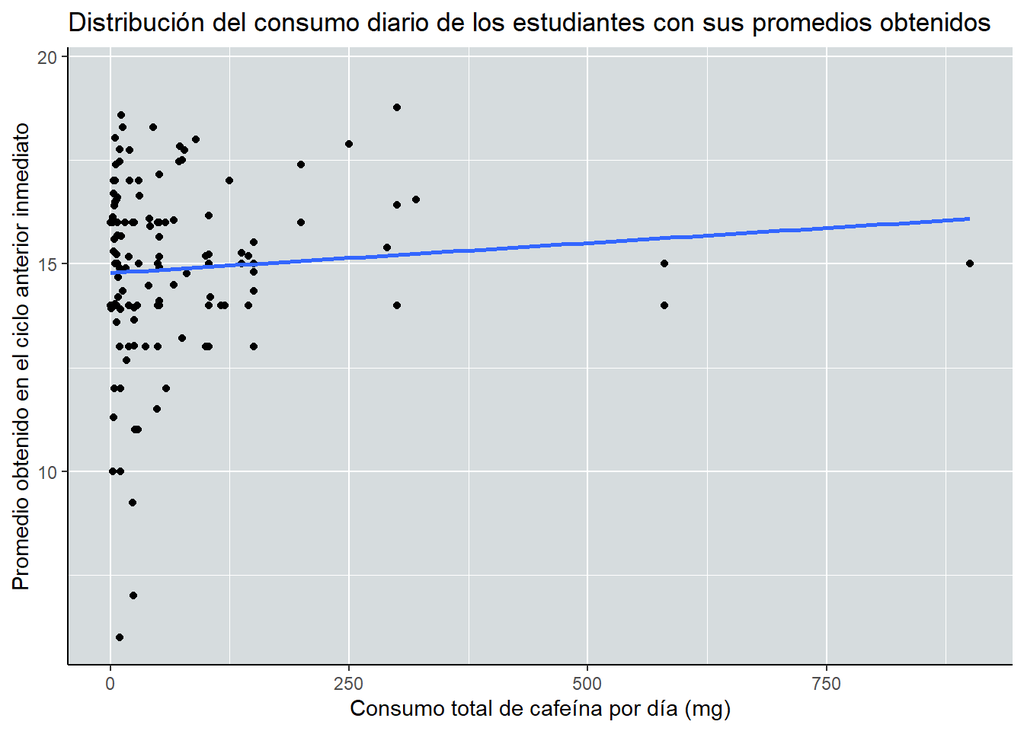

A continuación se muestra la correlación entre ambas variables.

```
## [1] 0.08
```

#### **Relación entre las variables *CONSUMO TOTAL DE CAFEINA (mg)* y *LA CANTIDAD DE CURSOS MATRICULADOS EN EL CICLO ANTERIOR*.**

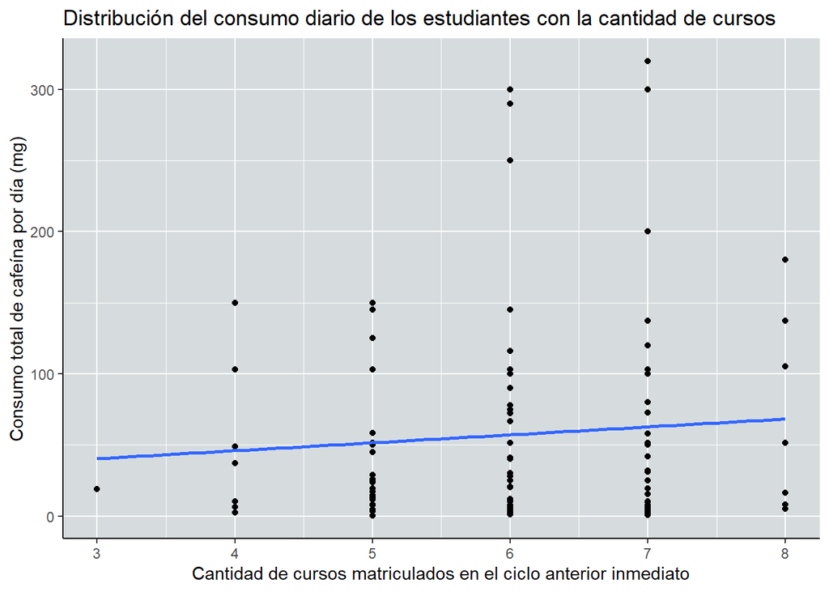

A continuación se muestra la correlación entre ambas variables.

[output not shown]

#### **Relación entre las variables *HORAS DESPIERTO CON BEBIDA ENERGETICA* y *PROMEDIO GENERAL DE LA CARRERA*.**

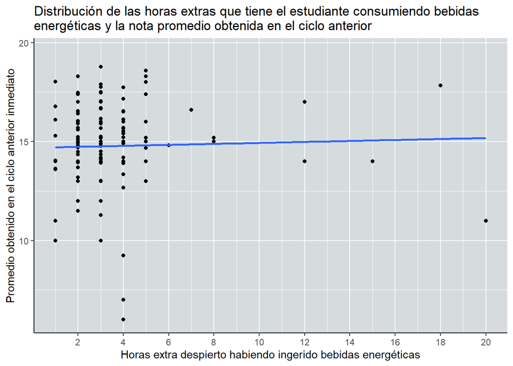

A continuación se muestra la correlación entre ambas variables.

```
## [1] 0.03
```

#### **Relación entre las variables *CONSUMO TOTAL DE CAFEINA (mg*) y *RANKING ACADÉMICO*.**

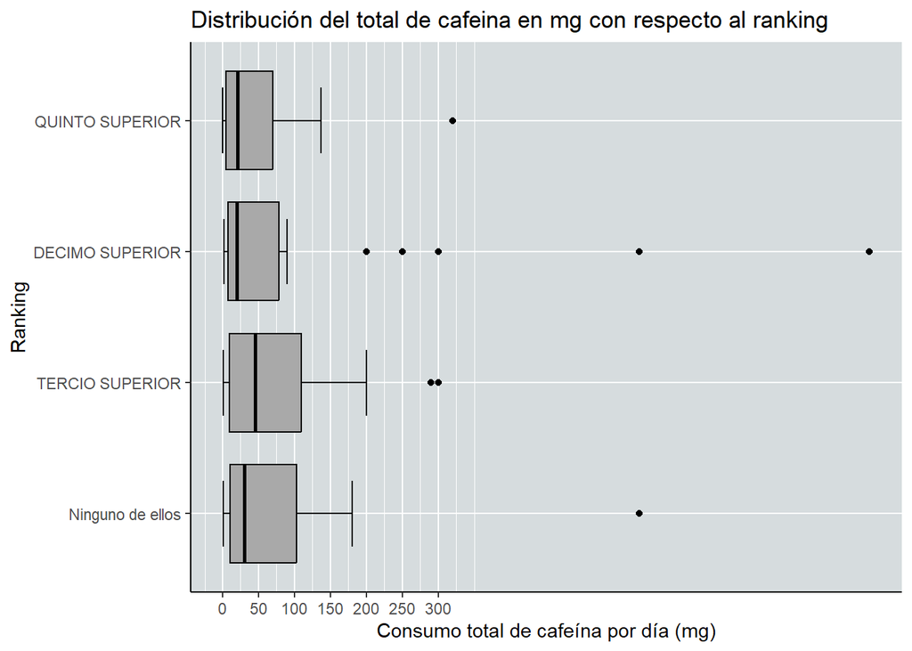

De la gráfica podemos decir que no hay una relación de gran medida entre el consumo de bebidas energéticas y el ranking académico, ya que una gran cantidad de estudiantes no alcanzaron un ranking a pesar de consumir cafeína. Además, que algunos estudiantes que ocupan el “Tercio superior” en el ranking académico consumen más cafeína que aquellos que no ocupan ningún ranking. No obstante, los que ocupan “Decimo superior” y “Quinto superior” consumen menos cafeína que aquellos que no ocupan un ranking lo que se puede interpretar que el consumo de cafeína no afecta significativamente el poder estar en un ranking académico.

#### **Análisis de las variables `Consumo_1_5`, `Consumo_6_10` y `Consumo_11_16`**

La relevancia para las variables `Consumo_1_5`, `Consumo_6_10`, `Consumo_11_16` está en ver si las semanas de lo que dura un ciclo afecta en el consumo de bebidas para el rendimiento académico; ya que un curso se puede volver más complicado y cansado en las etapas finales.

Como ya hemos calculado anteriormente cuál es la cantidad semanal promedio de mg de cafeína que consume un estudiante, procederemos a calcular el promedio de consumo en estos periodos, para identificar si existe una relación.

A continuación se calcula el promedio de consumo semanal de cada uno de los periodos en los que dividimos el ciclo. El primer valor hace referencia a cuántos miligramos de cafeína se consume semanalmente en el periodo de la semana 1 a la semana 5, el segundo valor hace referencia a cuánta cafeína semanal se consume en promedio de la semana 6 a la semana 10, de igual forma con el último valor hasta la semana 16.

Dichos promedios son los siguientes:

```
## [1] 348.89
```

```
## [1] 417.73
```

```
## [1] 395.03
```

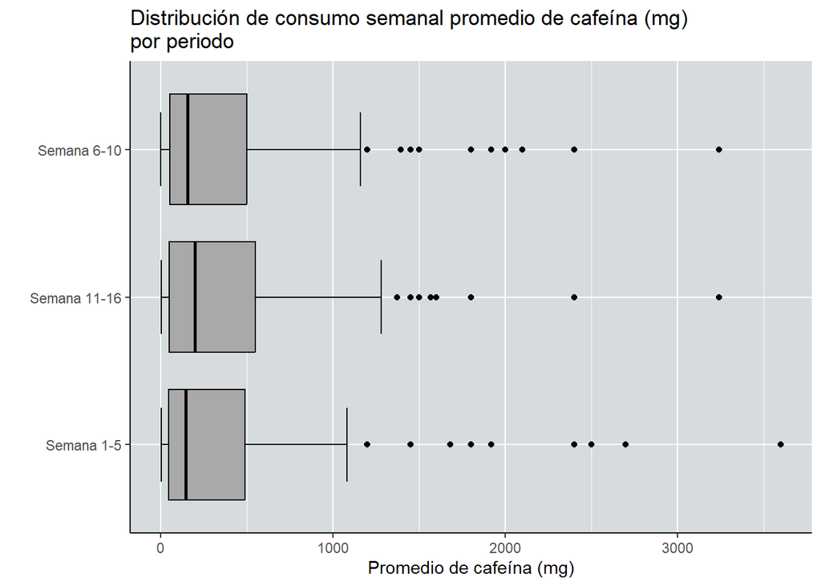

## **Variables aleatorias**

#### **Aproximación a una distribución normal de nuestra variable “total de cafeína”**

Como primera parte trabajaremos con la variable consumo total de miligramos de cafeína y utilizaremos el **Teorema central del límite** para aproximar esta distribución de datos a una distribución normal. Dado que en este caso tenemos más de 30 observaciones efectivas.

Para ello procedemos a calcular el promedio y la varianza de los datos, que viene a estar dada por la varianza dividido sobre la cantidad de datos que se tienen.

```
## [1] 71.13896
```

```
## [1] 93.33443
```

De tal forma que la aproximación de nuestra distribución normal queda de la siguiente forma:

[figure not shown]

```r
pnorm(400,mean=media,sd=sqrt(varianza),lower.tail = FALSE)
```

```
## [1] 2.838657e-254
```

Como podemos evidenciar, esto representa según la distribución normal un caso que se acerca a lo imposible. Este dato resulta relevante para el estudio ya que conocemos la probabilidad de que los estudiantes de la Universidad de Ingeniería y Tecnología consuman más de 400 mg de cafeína diaria que es lo máximo recomendado según la *Food and Drug Administration* (FDA). En ese sentido, saber que la probabilidad es baja resulta favorable ya que significa que muy pocos estudiantes sufrirán las consecuencias de consumir cantidades superiores a los 400 mg de cafeína, los cuales son: mareos, taquicardias, entre otros que podrían poner en riesgo su salud, como lo detalla la FDA (2018).

#### **Aproximación a una distribución normal de nuestra variable “horas dormido con bebida energética”**

Como primera parte trabajaremos con la variable horas dormido con bebida energética y utilizaremos el **Teorema central del límite** para aproximar esta distribución de datos a una distribución normal. Dado que en este caso tenemos más de 30 observaciones efectivas.

Para ello procedemos a calcular el promedio y la varianza de los datos, que viene a estar dada por la varianza dividido sobre la cantidad de datos que se tienen.

```
## [1] 5.511
```

```
## [1] 0.016
```

De tal forma que la aproximación de nuestra distribución normal queda de la siguiente forma:

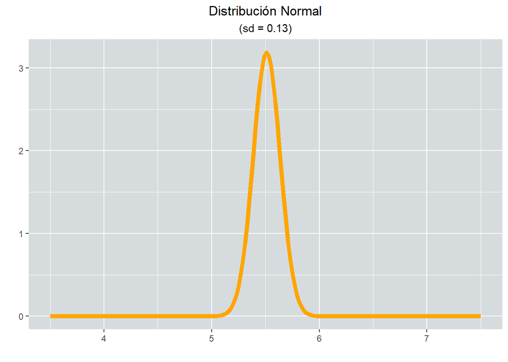

A partir de lo que tenemos en dicha distribución, se hace el cálculo de la probabilidad de que un estudiante considerado como adulto de más de 18 años duerma menos de las horas mínimas recomendadas el cual es de 6 horas según la revista Health Day. Por tanto, hallamos la probabilidad de horas de sueño menor a 6 horas.

```r
pnorm(6,mean=media1,sd=sqrt(varianza1),lower.tail = TRUE)
```

```
## [1] 0.9999534
```

Como podemos apreciar en base a esta aproximación a una distribución normal, la probabilidad de que un estudiante duerma menos de 6 horas es muy alta, casi totalmente probable, con un valor de 99.99 % lo que a su vez resulta un dato desconcertante ya que se se aprecia que al consumir bebidas energéticas que contienen cafeína los estudiantes duermen menos horas de las recomendadas lo que significa que muchos de ellos sufrirán consecuencias en su salud como cansancio, latidos acelerados, mareos y dolores de cabeza. Finalmente no se recomienda consumir este tipo de bebidas ya que más allá de beneficiar, lo que hacen es perjudicar.

## **Bibliografía**

- Coll, V. (n.d). Iniciación a la visualización de datos. Recuperado de: https://www.uv.es/vcoll/Temas_AED/4_Visualizacion_datos.html
- Campitelli, E. (2018, 1 de Junio). Tu propio smooth en geom_smooth(). Recuperado de: https://eliocamp.github.io/codigo-r/2018/06/tu-propio-geom-smooth/
- Need help with error when running “geom_smooth()` using formula ‘y ~ x’”. (2021, enero 11). RStudio Community. Recuperado de: https://community.rstudio.com/t/need-help-with-error-when-running-geom-smooth-using-formula-y-x/92890
- Preidt, R. (2011, septiembre 12). Los estudiantes universitarios no duermen lo suficiente. *Consumer Health News | HealthDay*. Recuperado de: https://consumer.healthday.com/kids-health-information-23/misc-kid-s-health-news-435/los-estudiantes-universitarios-no-duermen-lo-suficiente-656786.html
- Rcharts. (n.d). Box plot por grupo en ggplot2. Recuperado de: https://r-charts.com/es/distribucion/box-plot-grupo-ggplot2/
- RPubs - Boxplots con ggplot2. (s/f). Rpubs.com. Recuperado el 24 de junio de 2022. Recuperado de: https://rpubs.com/MrCristianrl/496859
- RPubs - GGPLOT2. Gráfico de barras IV - Reordenar barras. (s/f). Rpubs.com. Recuperado el 24 de junio de 2022, de https://rpubs.com/Rortizdu/140196